# Statistica Medica — Corrado Lanera – Statistica Medica

# Statistica Medica

Introduzione a R/RStudio

Corrado Lanera

[Unità di Biostatistica, Epidemiologia e Salute Pubblica](https://www.unipd-ubep.it/), Università di Padova

10 novembre 2026

## Cosa faremo

Nella prossima ora vi fornirò un’introduzione all’uso di **R**, tramite **RStudio**. Vedremo **cosa sono**, **a cosa servono** (in cosa si differenziano) e come installarli.

L’obiettivo principale è quello di fornirvi gli elementi **base** per poter (se volete, vi fa piacere, o pensate possa esservi utile*) seguire *anche* la fase di codifica degli esempi interattivi ed esercitazioni che vi mostrerò nelle future lezioni.

Inoltre, ho messo a disposizione (**gratuitamente**) un ambiente di lavoro Posit Cloud attivabile da ciascuno di voi (vedremo come), in modo che possiate usare R/RStudio senza doverli installare, e con/su qualunque dispositivo vi troviate a operare.**

* La mia opinione in merito, chiaramente, è: *si* 😉.

** Volendo, anche su smartphone e tablet, seppur piuttosto scomodo!

## Panoramica

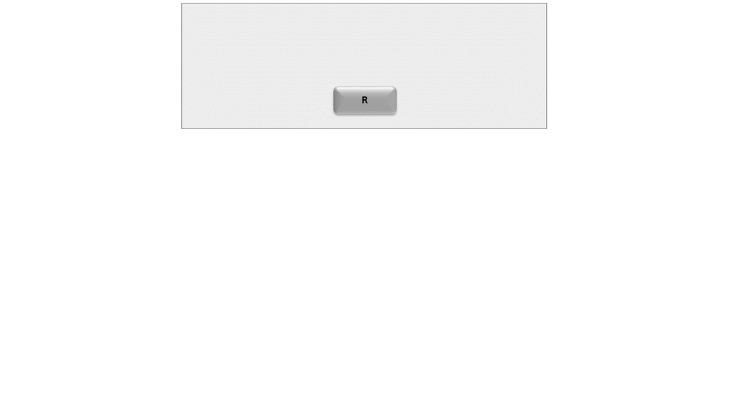

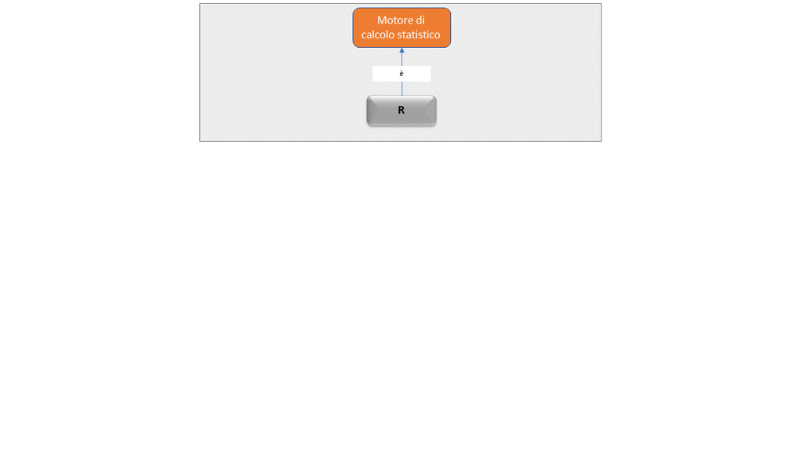

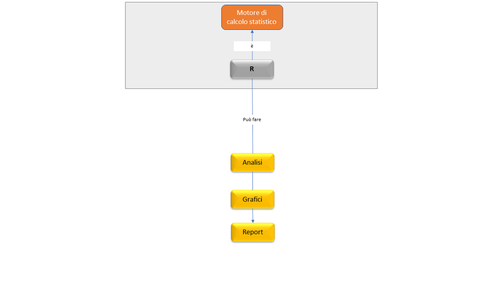

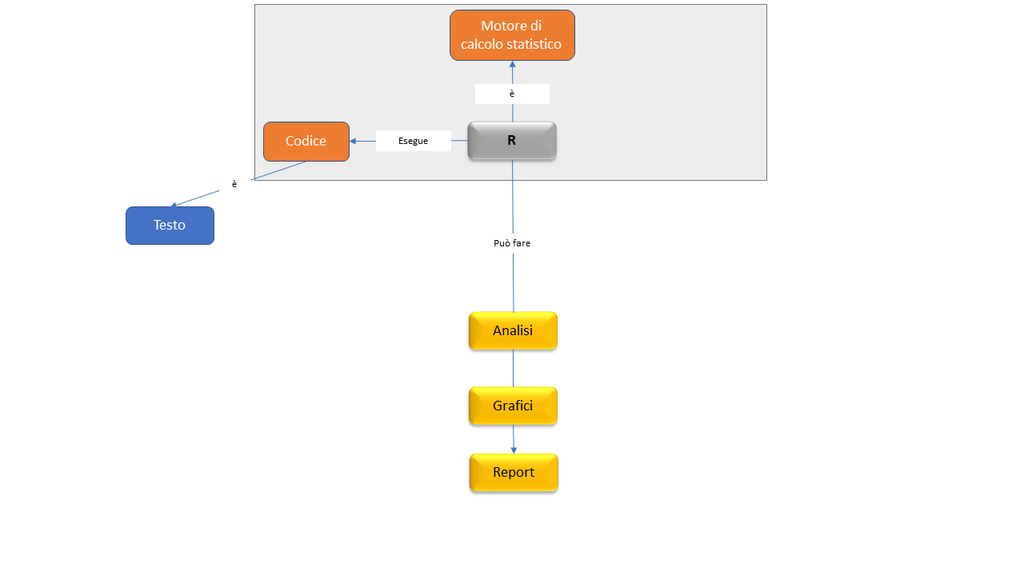

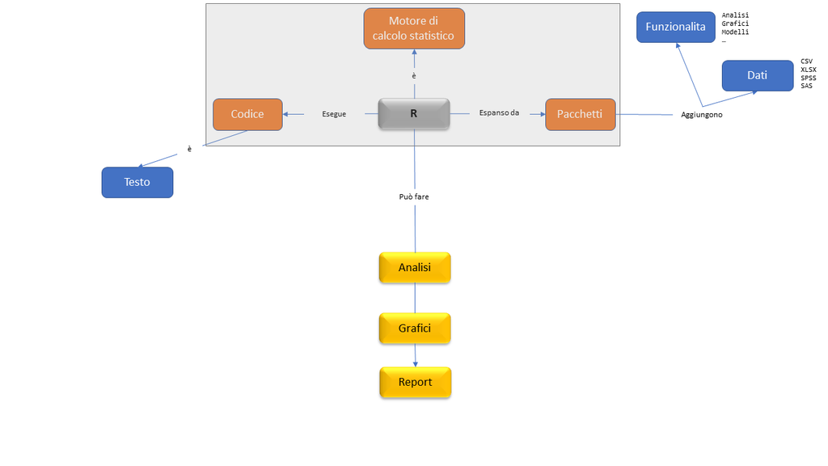

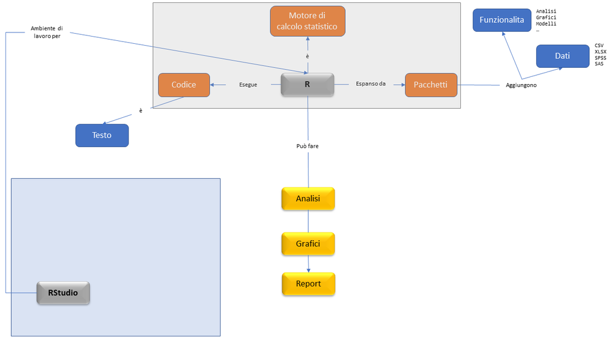

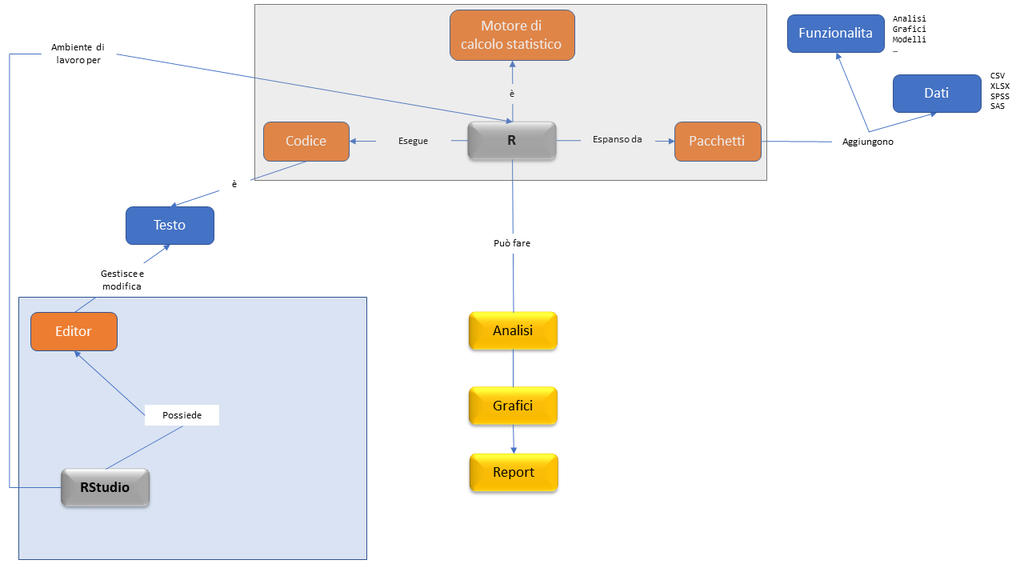

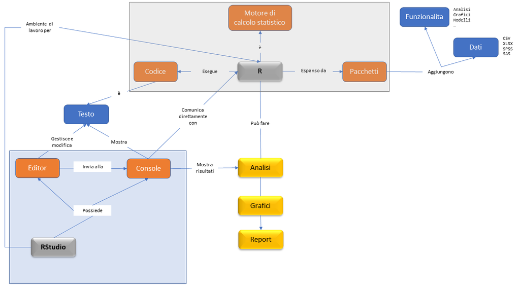

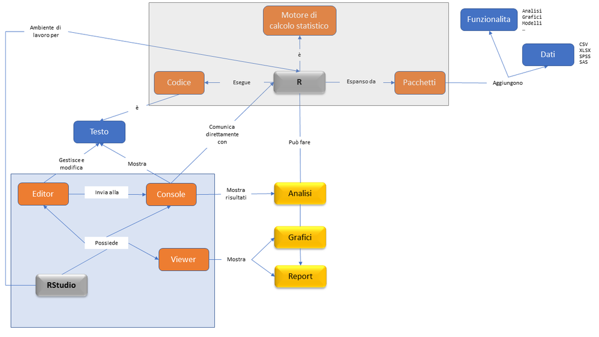

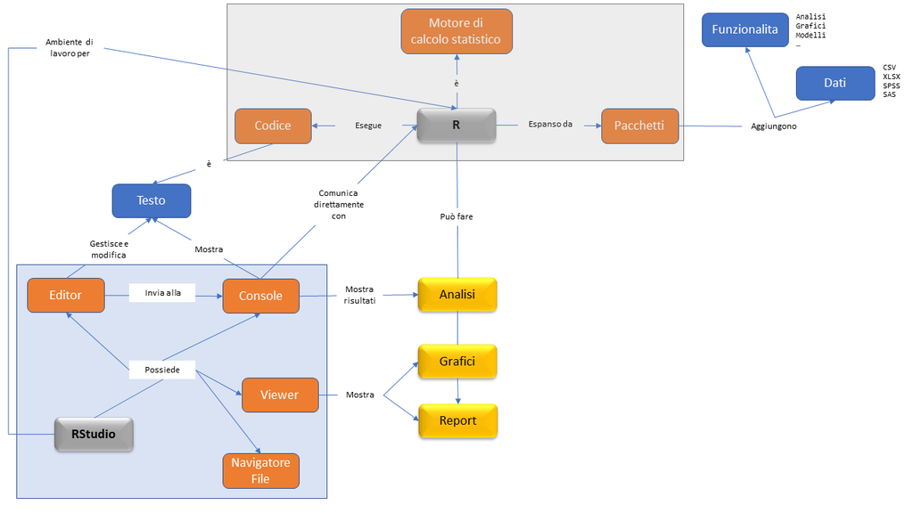

## Mappa: R e RStudio in breve

- Mappa
- Indice

[output not shown]

Ogni freccia va da un concetto a quelli che lo usano. In grigio i concetti delle sezioni o dei deck precedenti (con il numero del deck).

- R (facoltativo)
- Analisi, grafici, report (facoltativo)
- Codice R (facoltativo)
- Pacchetto (facoltativo)
- RStudio (facoltativo)
- Editor (facoltativo)
- Console (facoltativo)
- Viewer (facoltativo)
- Navigatore file (facoltativo)

[figure not shown]

## Installazione

### Go to: https://cloud.r-project.org/

[interactive chart not shown]

## Algebra elementare

In R possiamo operare tutte le operazioni algebriche di base, e anche di più! Ottimo quindi anche come calcolatrice potenziata!

```r
1 + 1  # sum
```

```
[1] 2
```

```r
7 * 3  # product
```

```
[1] 21
```

```r
abs(-2)  # absolute value
```

```
[1] 2
```

```r
3^2  # power
```

```
[1] 9
```

```r
sqrt(9)  # square root
```

```
[1] 3
```

## Vettori

La struttura base dei dati in R è il vettore: sequenze di valori dello stesso tipo (numeri, testo, logici)

```r
c(1, 2, 3, 7)  # concatenate
```

```
[1] 1 2 3 7
```

```r
1:7  # sequence
```

```
[1] 1 2 3 4 5 6 7
```

```r
seq_len(4)  # sequence
```

```
[1] 1 2 3 4
```

```r
rep(2, 3)  # replicate
```

```
[1] 2 2 2
```

```r
rev(c(1, 2, 3))  # reverse
```

```
[1] 3 2 1
```

## Assegnamento (“memorizzazione”)

Spesso può essere utile salvare il risultato di una operazione o della chiamata di una funzione in un oggetto (che chiamiamo **variabile**) a cui possiamo assegnare un nome.

```r
first_vector <- 1:10
first_vector
```

```
 [1]  1  2  3  4  5  6  7  8  9 10
```

```r
first_vector + 5
```

```
 [1]  6  7  8  9 10 11 12 13 14 15
```

## Confronti (Booleani)

Possiamo fare confronti ottenendo dei risultati **logici**: `TRUE`/`FALSE`.

```r
1 == 0
```

```
[1] FALSE
```

```r
1 != 0
```

```
[1] TRUE
```

```r
1 > 0
```

```
[1] TRUE
```

```r
1 <= 0
```

```
[1] FALSE
```

## Logica (Booleana)

Possiamo anche fare operazioni direttamente con vettori logici

```r
TRUE & FALSE
```

```
[1] FALSE
```

```r
TRUE | FALSE
```

```
[1] TRUE
```

```r
!TRUE
```

```
[1] FALSE
```

## Logica (Booleana, … vettoriale)

```r
c(TRUE, FALSE) & c(FALSE, FALSE)
```

```
[1] FALSE FALSE
```

```r
c(1, 2, 3, 3, 2, 4) == 2
```

```
[1] FALSE  TRUE FALSE FALSE  TRUE FALSE
```

```r
which(c(1, 2, 3, 3, 2, 4) == 2)
```

```
[1] 2 5
```

```r
# WARNING
c(TRUE, FALSE, NA) & FALSE
```

```
[1] FALSE FALSE FALSE
```

```r
c(TRUE, FALSE, NA) & TRUE
```

```
[1]  TRUE FALSE    NA
```

## Dataframe

- ogni riga è un’osservazione (es: un paziente, o una visita)
- ogni colonna è una variabile (es: il genere, o l’età)

```r
first_df <- data.frame(
  id     = c(7, 12, 31),
  gender = factor(
      c('m', 'm', 'f'),
      levels = c('f', 'm', 'non-binary', 'unknown')
  ),
  city   = c('Gorizia', 'Viterbo', 'Napoli'),
  height = c(1.84, 1.70, 1.59),
  weight = c(115, 70, 51),
  overweight = c(TRUE, FALSE, FALSE)
)
first_df
```

```
  id gender    city height weight overweight
1  7      m Gorizia   1.84    115       TRUE
2 12      m Viterbo   1.70     70      FALSE
3 31      f  Napoli   1.59     51      FALSE
```

## Pacchetti

Un pacchetto di espansione di R è una collezione di funzioni e/o di dati che possono essere “aggiunti” al proprio ambiente di lavoro.

Si installano una sola volta (in generale, salvo aggiornamenti) ma si caricano ogni volta (una sola volta) che si ricomincia a lavorare.

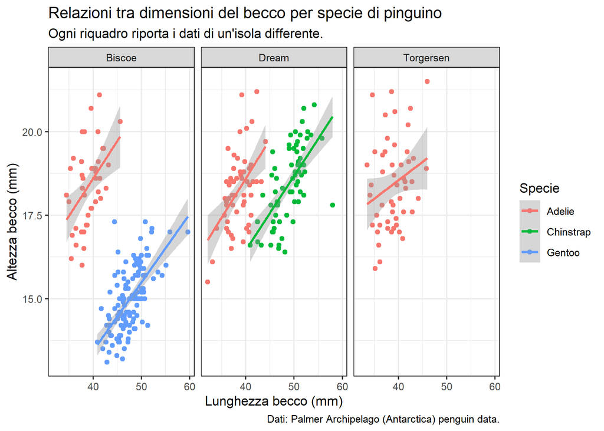

```r
library('tidyverse')
library('palmerpenguins')

ggplot(
    penguins,
    aes(x = bill_length_mm, y = bill_depth_mm, colour = species)
  ) +
  geom_point() +
  geom_smooth(method = lm) +
  facet_wrap(island~.) +
  labs(
    x = "Lunghezza becco (mm)",
    y = "Altezza becco (mm)",
    colour = "Specie",
    title = "Relazioni tra dimensioni del becco per specie di pinguino",
    subtitle = "Ogni riquadro riporta i dati di un'isola differente.",
    caption = "Dati: Palmer Archipelago (Antarctica) penguin data."
  ) +
  theme_bw()
```

## Mappa: R

- Mappa
- Indice

[output not shown]

Ogni freccia va da un concetto a quelli che lo usano. In grigio i concetti delle sezioni o dei deck precedenti (con il numero del deck).

- Installare R (facoltativo)
- Aritmetica (facoltativo)
- Tipi di dato (facoltativo)
- Vettore (facoltativo)
- Assegnamento (facoltativo)
- Confronti (facoltativo)
- Operatori logici (facoltativo)
- Vettorizzazione (facoltativo)
- which() (facoltativo)
- NA (facoltativo)
- Dataframe (facoltativo)
- Fattore (facoltativo)
- Caricare pacchetti (facoltativo)

## Installazione

#### Go to: https://posit.co/download/rstudio-desktop/

## Vediamolo… …sul *vostro* cloud!

https://bit.ly/statmed-cl-rstudio

## Mappa: tutte le sezioni

- Mappa
- Blocchi

[output not shown]

Ogni freccia va da un concetto a quelli che lo usano. Ogni riquadro è un blocco di concetti che si usano insieme; fra parentesi quanti sono.

- **R e RStudio**: R, Analisi, grafici, report, Codice R, Pacchetto, RStudio, Editor, Console, Viewer, Navigatore file, Posit Cloud, Installare R, Installare RStudio
- **Oggetti e operazioni**: Aritmetica, Tipi di dato, Vettore, Assegnamento, Vettorizzazione, which()
- **Confronti e logica**: Confronti, Operatori logici, NA
- **Dati e pacchetti**: Dataframe, Fattore, Caricare pacchetti

## Risorse utili

- [**Posit Cloud**](https://bit.ly/statmed-cl-rstudio): bit.ly/statmed-cl-rstudio gratis per voi per esplorare RStudio, le sue funzionalità, e allenarvi con R (link di iscrizione valido fino alla fine del corso).
- [Base R workshop for Data Science](https://bit.ly/ubep-rws-slide): bit.ly/ubep-rws-slide - materiale base per un workshop di 16 ore su R (4 ore x 4 giorni), con esempi, codice, esercizi, ambiente di lavoro. (NO modelli, NO (bio-)statistica)
- [**RStudio primers**](https://posit.cloud/learn/primers) ambiente gratuito dentro Posit Cloud per l’apprendimento delle basi di analisi di dati con R tramite tutorial interattivi. Una volta registrati, oltre all’accesso al *nostro* spazio di lavoro, avete accesso libero anche ai *Primers*.
- [**R 4 Data Science**](https://r4ds.hadley.nz/): libro gratuito (on-line) di [**Hadley Wickham**](http://hadley.nz/), **Mine Çetinkaya-Rundel** e **Garrett Grolemund**
- [**Advanced R**](https://adv-r.hadley.nz/): libro gratuito (on-line) di [**Hadley Wickham**](http://hadley.nz/); suggeriti capitolo 1-6 (che non sono “Advanced” ma semplicemente “Correct”).

## Break

Consigli:

- alzarsi
- sgranchirsi
- guardare *lontano* (rilassare gli occhi)
- bere
- andare in bagno

If you think the only acceptable performance is the “perfect performance”,  
AI is not for you!  
But, I’ve heard that even humans have made mistakes…

— Daniel Oberski  
2021/03/26 ASReview interview  
https://daob.nl/

### Grazie per l’attenzione!

Diapositive: bit.ly/cl-statmed

[**www.unipd-ubep.it**](https://www.unipd-ubep.it/) | **Corrado.Lanera@ubep.unipd.it**

**@CorradoLanera** | [**bit.ly/statmed-cl-ricevimento**](https://bit.ly/statmed-cl-ricevimento)